# Can We Predict Patterns of Hospitalizations Across States?

Bracken Sant

```r
library(mosaic)
library(pander)
library(car)
library(tidyverse)
library(ggplot2)
library(rio)
library(alr4)
library(lubridate)
```

# Introduction

We will be exploring Covid-19 data from two states, California and New York. I will make a model for both California and New York to predict the number of Hospitalizations, due to covid, based off of the case count and other variables from 7 days prior. With this I hope to be able to help hospitals be more prepared for big surges so that they will be able to assist more people and won’t be as overworked.

## New York Data and Model

```r
vacs <- read_csv("vaccinations.csv", show_col_types = FALSE)

hosp <- read_csv("hospitalizations.csv", show_col_types = FALSE)

ny_data <- import("https://raw.githubusercontent.com/nychealth/coronavirus-data/master/trends/data-by-day.csv") %>%
  mutate(
    date_of_interest = mdy(date_of_interest)
  ) %>%
  select(date_of_interest, CASE_COUNT, HOSPITALIZED_COUNT, DEATH_COUNT)



vacs_ny <- vacs %>%
  filter(location_key == "US_NY")

hosp_ny <- hosp %>%
  filter(location_key == "US_NY")

vacs_hosp_all_ny_data <- hosp_ny %>%
  left_join(vacs_ny, join_by("location_key"=="location_key", "date"=="date"))



data_all_ny <- ny_data %>%  left_join(vacs_hosp_all_ny_data, join_by("date_of_interest"=="date")) %>%
  fill(c("new_persons_vaccinated", "new_persons_fully_vaccinated", "new_vaccine_doses_administered", "cumulative_persons_vaccinated", "cumulative_persons_fully_vaccinated", "cumulative_vaccine_doses_administered"), .direction="down") %>%
  replace_na(replace = list("new_hospitalized_patients" = 0,
                            "current_hospitalized_patients" = 0,
                            "new_ventilator_patients" = 0, "current_ventilator_patients" = 0,
                            "new_persons_vaccinated" = 0,"new_persons_fully_vaccinated" = 0,
                            "new_vaccine_doses_administered" = 0, "CASE_COUNT" = 0, "HOSPITALIZED_COUNT" = 0,
                            "DEATH_COUNT" = 0, "cumulative_hospitalized_patients" = 0,
                            "cumulative_ventilator_patients" = 0,
                            "cumulative_persons_vaccinated" = 0, "cumulative_persons_fully_vaccinated" = 0,
                            "cumulative_vaccine_doses_administered" = 0)) %>%
  select(-contains("pfizer"), -contains("moderna"), -contains("janssen"),
         -contains("sinovac"), -c("location_key"), -contains("intensive"),
         -c("new_ventilator_patients", "location_key", "cumulative_ventilator_patients"),
         -contains("vaccine_doses"))



cases <- data_all_ny %>% select(date_of_interest, HOSPITALIZED_COUNT)
everything_else <- data_all_ny %>% select(!c(HOSPITALIZED_COUNT))

everything_else_up7 <- everything_else  %>% mutate(
  date_of_interest = lubridate::as_date(date_of_interest) + 7
)

adjusted_dates_complete <- cases %>% left_join(everything_else_up7, by="date_of_interest")
adjusted_dates_complete <- adjusted_dates_complete[8:930, ] %>%
  mutate(
    full_vacs_G_mean = factor(ifelse(cumulative_persons_fully_vaccinated > mean(cumulative_persons_fully_vaccinated), "fullVacs>Mean", "fullVacs<Mean")),
    ventilator_patients = factor(ifelse(current_ventilator_patients > 0, "VentPat", "NoVentPat"))
  ) %>%
  select(date_of_interest, HOSPITALIZED_COUNT, CASE_COUNT, full_vacs_G_mean, ventilator_patients, cumulative_persons_fully_vaccinated, current_ventilator_patients)
```

**Data Set Information**

- The `HOSPITALIZED_COUNT` and `CASE_COUNT` columns come from this [link](https://data.cityofnewyork.us/Health/COVID-19-Daily-Counts-of-Cases-Hospitalizations-an/rc75-m7u3/about_data) and show the count of hospitalizations and cases for covid-19 on a given day.
- The `full_vacs_G_mean` column is a True/False factor that shows if the `cumulative_persons_fully_vaccinated` is greater than its mean, in this case the mean was a little over 7 million.
- The `ventilator_patients` column is a True/False factor that shows if there are patients on a ventilator in the hospital given by this column `current_ventilator_patients`.
- The `full_vacs_G_mean` and `ventilator_patients` are never both True at the same time in the data set.
- All of the columns besides `HOSPITALIZED_COUNT` are set forward by 7 days, so we are using data from 7 days prior to predict the `HOSPITALIZED_COUNT`. I chose 7 days because that was the average time it took to display symptoms after being infected. [cdc](https://www.cdc.gov/coronavirus/2019-ncov/symptoms-testing/symptoms.html)

The other Data in the table I got from [Covid Vaccine and Specific Hospital Data Sets](https://github.com/GoogleCloudPlatform/covid-19-open-data/tree/main/docs).

#### Table

```r
DT::datatable(adjusted_dates_complete %>% select(date_of_interest, HOSPITALIZED_COUNT, CASE_COUNT, full_vacs_G_mean, ventilator_patients))
```

|  | date_of_interest | HOSPITALIZED_COUNT | CASE_COUNT | full_vacs_G_mean | ventilator_patients |
| --- | --- | --- | --- | --- | --- |
| 8 | 2020-03-07 | 8 | 1 | fullVacs&lt;Mean | NoVentPat |
| 9 | 2020-03-08 | 18 | 0 | fullVacs&lt;Mean | NoVentPat |
| 10 | 2020-03-09 | 37 | 0 | fullVacs&lt;Mean | NoVentPat |
| 11 | 2020-03-10 | 60 | 1 | fullVacs&lt;Mean | NoVentPat |
| 12 | 2020-03-11 | 78 | 5 | fullVacs&lt;Mean | NoVentPat |
| 13 | 2020-03-12 | 106 | 3 | fullVacs&lt;Mean | NoVentPat |
| 14 | 2020-03-13 | 152 | 8 | fullVacs&lt;Mean | NoVentPat |
| 15 | 2020-03-14 | 177 | 7 | fullVacs&lt;Mean | NoVentPat |
| 16 | 2020-03-15 | 210 | 21 | fullVacs&lt;Mean | NoVentPat |
| 17 | 2020-03-16 | 338 | 57 | fullVacs&lt;Mean | NoVentPat |

[output cut: 913 more lines]

### Making the Model

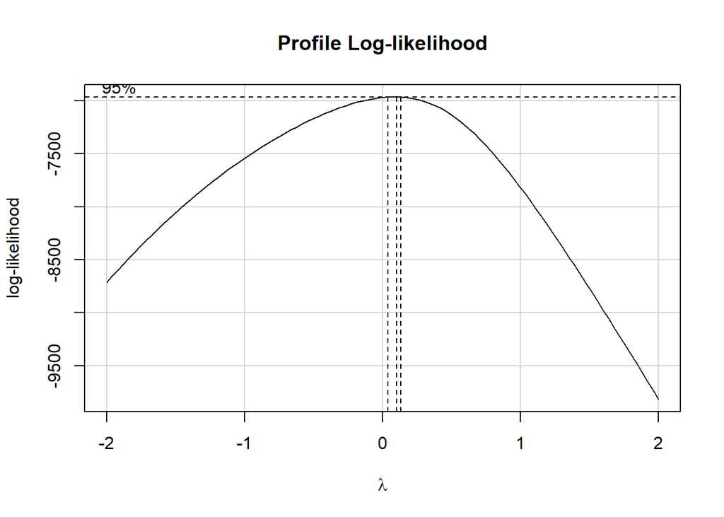

```r
lm_covid_ny_non <- lm(HOSPITALIZED_COUNT~(CASE_COUNT) + CASE_COUNT:full_vacs_G_mean + CASE_COUNT:ventilator_patients, adjusted_dates_complete)

boxCox(lm_covid_ny_non)
```

The $\lambda$ appears to be close to 0, so we will make a log transformation.

```r
lm_covid_ny <- lm(log(HOSPITALIZED_COUNT)~(CASE_COUNT) + CASE_COUNT:full_vacs_G_mean + CASE_COUNT:ventilator_patients, adjusted_dates_complete)
summary(lm_covid_ny)
```

```
##
## Call:
## lm(formula = log(HOSPITALIZED_COUNT) ~ (CASE_COUNT) + CASE_COUNT:full_vacs_G_mean +
##     CASE_COUNT:ventilator_patients, data = adjusted_dates_complete)
##
## Residuals:
##      Min       1Q   Median       3Q      Max
## -2.11945 -0.41486 -0.02663  0.43254  2.20117
##
## Coefficients:
##                                            Estimate Std. Error t value Pr(>|t|)
## (Intercept)                               4.031e+00  2.538e-02 158.820  < 2e-16
## CASE_COUNT                                6.060e-04  2.038e-05  29.730  < 2e-16
## CASE_COUNT:full_vacs_G_meanfullVacs>Mean -5.166e-04  2.025e-05 -25.512  < 2e-16
## CASE_COUNT:ventilator_patientsVentPat    -1.732e-04  2.497e-05  -6.934  7.7e-12
##
## (Intercept)                              ***
## CASE_COUNT                               ***
## CASE_COUNT:full_vacs_G_meanfullVacs>Mean ***
## CASE_COUNT:ventilator_patientsVentPat    ***
## ---
## Signif. codes:  0 '***' 0.001 '**' 0.01 '*' 0.05 '.' 0.1 ' ' 1
##
## Residual standard error: 0.6219 on 919 degrees of freedom
## Multiple R-squared:  0.6303, Adjusted R-squared:  0.6291
## F-statistic: 522.3 on 3 and 919 DF,  p-value: < 2.2e-16
```

```r
b_ny <- coef(lm_covid_ny)
```

All of the features used show significant p-values below 0.001, so they would be able to be used even with the lowest significance level on the summary. The R-squared is around .63 which shows a moderate to strong correlation and by looking at the slope estimates we can see that it is a positive correlation between `CASE_COUNT` and `HOSPITALIZED_COUNT`.

The cumulative full vaccinations > 7 million appears to be very meaningful as well as the variable of if the state had ventilator patients in hospitals. I believe that it might not be as much about the vaccinations as it was about the timing of when the cumulative full vaccinations rose above 7 million, which was 2021-05-14. This is when cold and flu type viruses usually taper off because temperatures start to rise and there aren’t as many fluctuations to the weather. This is also about a year after the pandemic began and when people would start building an immunity to it naturally; however, the vaccinations might have been a factor as well. The same with ventilator patients in hospitals which appeared to only be at the beginning of the pandemic and before the cumulative full vaccinations rose above 7 million.

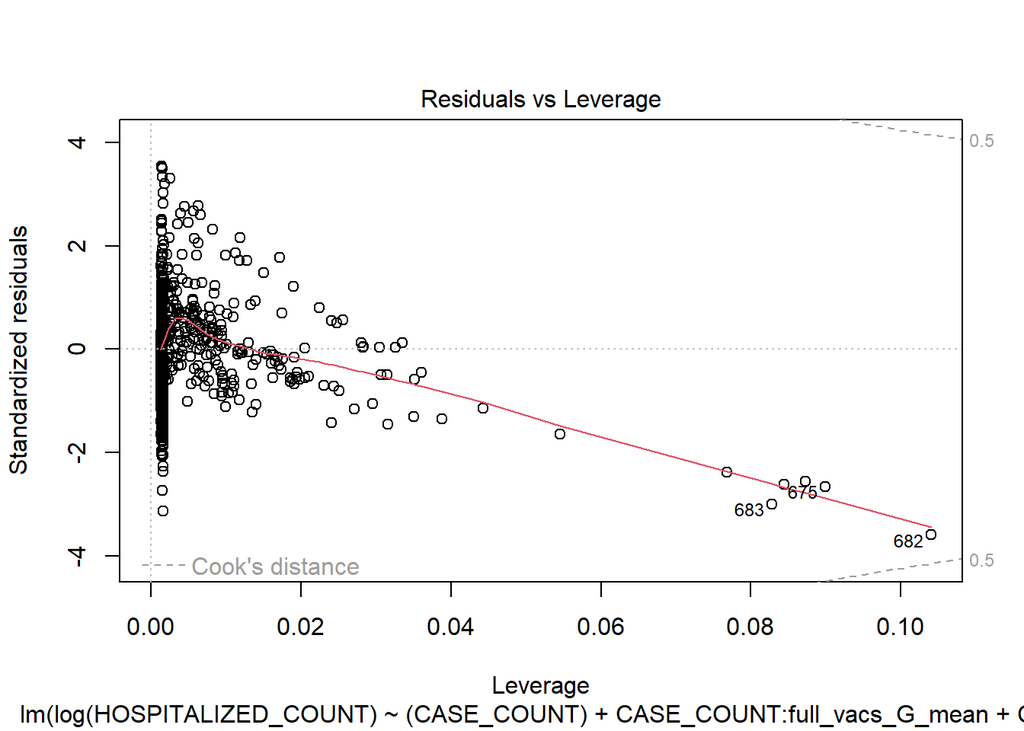

```r
plot(lm_covid_ny, which=c(5))
```

#### Explanation:

In the Cook’s distance graph above, none of the points go out of the .5 bounds so I will not make any adjustments to the data.

### Graphing the Model

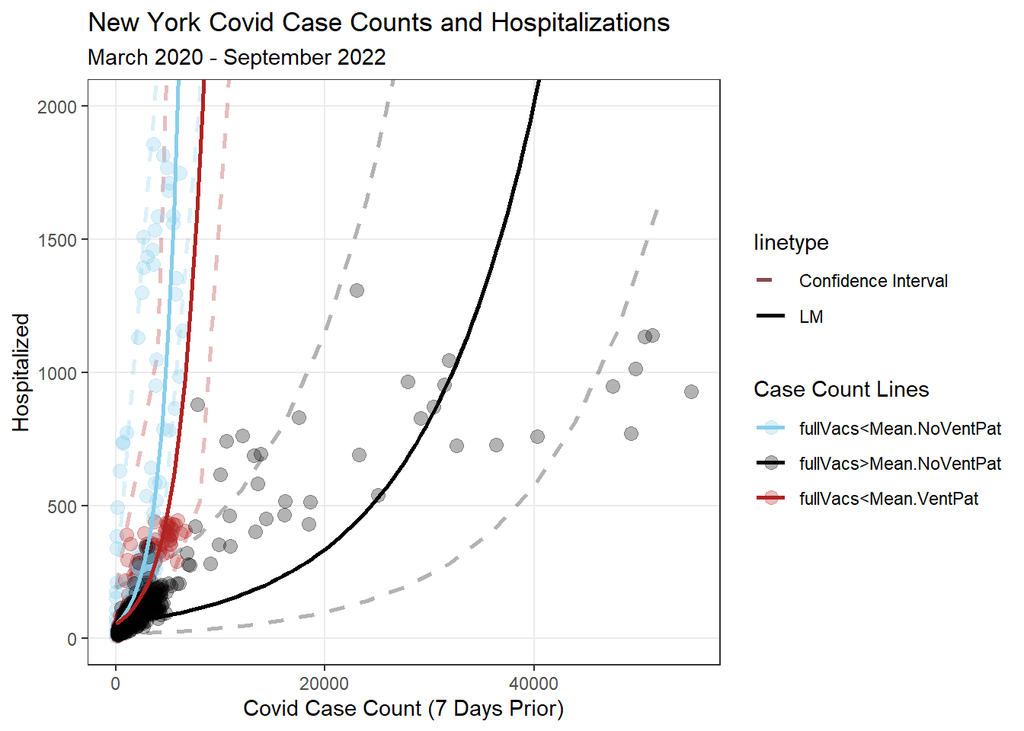

```r
drawit_ny <- function(CASE_COUNT, fullVacsMean = 0, VentPat = 0){
  exp(b_ny[1] + b_ny[2]*CASE_COUNT + b_ny[3]*CASE_COUNT*fullVacsMean + b_ny[4]*CASE_COUNT*VentPat)
}

get_pred <- function(fullVacsMean = "fullVacs<Mean", VentPat = "NoVentPat"){
  CASE_COUNT <- seq(0, max(adjusted_dates_complete$CASE_COUNT), 4000)
  fullVacs_list <- rep(c(fullVacsMean),(max(adjusted_dates_complete$CASE_COUNT)/4000)+1)
  VentPat_list <- rep(c(VentPat),(max(adjusted_dates_complete$CASE_COUNT)/4000)+1)

  allpreds <- exp(predict(lm_covid_ny, data.frame(CASE_COUNT=CASE_COUNT, full_vacs_G_mean=fullVacs_list, ventilator_patients = VentPat_list), interval="prediction"))

  allpreds <- data.frame(allpreds, CASE_COUNT = CASE_COUNT, fullVacsMean = fullVacs_list, VentPat = VentPat_list)

  return(allpreds)
}

allpreds_blue <- get_pred("fullVacs<Mean", "NoVentPat")
allpreds_black <- get_pred("fullVacs>Mean", "NoVentPat")
allpreds_red <- get_pred("fullVacs<Mean", "VentPat")


ggplot(adjusted_dates_complete, aes(x=CASE_COUNT, y=HOSPITALIZED_COUNT)) +
  geom_line(data=allpreds_blue, mapping=aes(x=CASE_COUNT, y=lwr, linetype="Confidence Interval"), color="skyblue", linewidth=1, alpha=.3) +
  geom_line(data=allpreds_blue, mapping=aes(x=CASE_COUNT, y=upr, linetype="Confidence Interval"), color="skyblue", linewidth=1, alpha=.3) +
  geom_line(data=allpreds_black, mapping=aes(x=CASE_COUNT, y=lwr, linetype="Confidence Interval"), color="black", linewidth=1, alpha=.3) +
  geom_line(data=allpreds_black, mapping=aes(x=CASE_COUNT, y=upr, linetype="Confidence Interval"), color="black", linewidth=1, alpha=.3) +
  geom_line(data=allpreds_red, mapping=aes(x=CASE_COUNT, y=lwr, linetype="Confidence Interval"), color="firebrick", linewidth=1, alpha=.3) +
  geom_line(data=allpreds_red, mapping=aes(x=CASE_COUNT, y=upr, linetype="Confidence Interval"), color="firebrick", linewidth=1, alpha=.3 ) +
  geom_point(aes(color=interaction(full_vacs_G_mean, ventilator_patients)), alpha=.3, size=3) +
  scale_color_manual(values=c("skyblue", "black", "firebrick")) +
  stat_function(fun=drawit_ny, args=list(fullVacsMean=0, VentPat=0), aes(color="fullVacs<Mean.NoVentPat", linetype="LM"), linewidth=1) +
  stat_function(fun=drawit_ny, args=list(fullVacsMean=1, VentPat=0), aes(color="fullVacs>Mean.NoVentPat", linetype="LM"), linewidth=1) +
  stat_function(fun=drawit_ny, args=list(fullVacsMean=0, VentPat=1), aes(color="fullVacs<Mean.VentPat", linetype="LM"), linewidth=1) +
  guides(color=guide_legend(title="Case Count Lines")) +
  scale_linetype_manual(values=c("Confidence Interval" = 2, "LM" = 1)) +
  coord_cartesian(ylim=c(0,2000)) +
  # facet_wrap(~interaction(full_vacs_G_mean, ventilator_patients)) +
  labs(
    x = "Covid Case Count (7 Days Prior)",
    y = "Hospitalized",
    title = "New York Covid Case Counts and Hospitalizations",
    subtitle = "March 2020 - September 2022"
  ) +
  theme_bw() +
  theme(panel.grid.minor = element_blank(),
        title = element_text(hjust=.5))
```

#### New York Model Explanation

I decided to look at two different parts of the graph for this since it can have varying slopes based on where it is on the graph.

**Black Line:** When the amount of full vaccinations is greater than the mean in the data set but there are not patients in the hospital on a ventilator (both 7 days prior to hospitalization predictions), the predicted count of hospitalizations, due to covid, for that day go up by (from 1 to 2 covid cases) $0.0050349$ per additional covid case 7 days prior. This means that it estimates for every 200 additional cases, at the beginning, it is predicted that there will be 1 additional hospitalization.

From 25000 to 25001 covid cases for this $0.0470406$ per additional covid case 7 days prior. This means that it estimates for every 20 to 22 additional cases, at the beginning, it is predicted that there will be 1 additional hospitalization.

From 4000 to 4001 covid cases $0.1377146$ per additional covid case 7 days prior. This means that it estimates for every 7 to 8 additional cases it is predicted that there will be 1 additional hospitalization.

### Assumptions

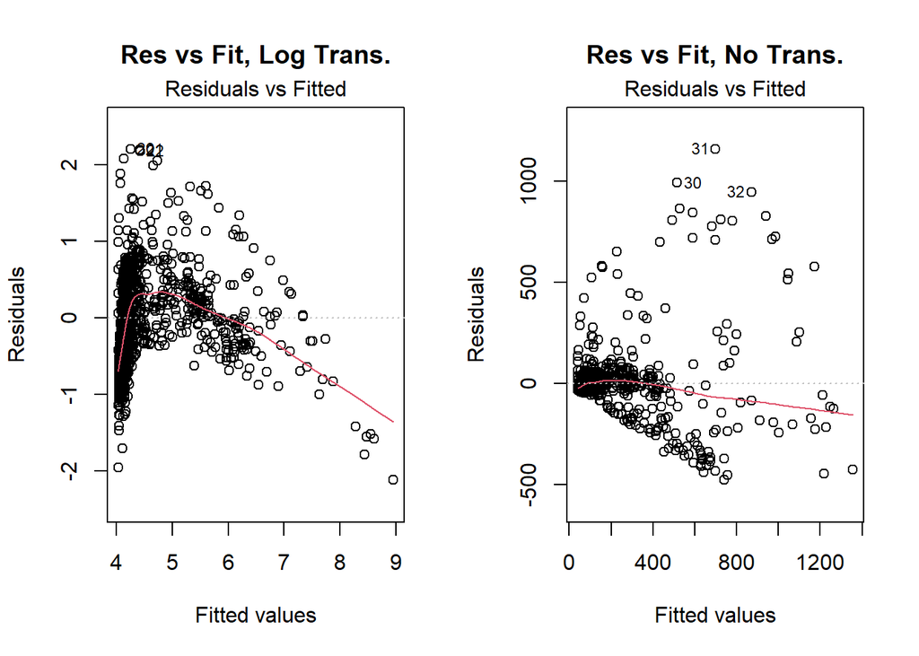

```r
par(mfcol=c(1,2))
plot(lm_covid_ny, which=1, main="Res vs Fit, Log Trans.")
plot(lm_covid_ny_non, which=1, main="Res vs Fit, No Trans.")
```

#### Explanation

There seems to be a megaphone shape in the Residuals, so it fails the constant variance test for the residuals. We will continue with the test, however. We will just not be able to reach any conclusions from the results. The results for this test look better in our non-transformed model, though it appears that there are some worrying points at the top (30, 31, 32).

```r
par(mfcol=c(1,2))
qqPlot(lm_covid_ny, main="qqPlot, Log Trans.")
```

```
##  20 682
##  13 675
```

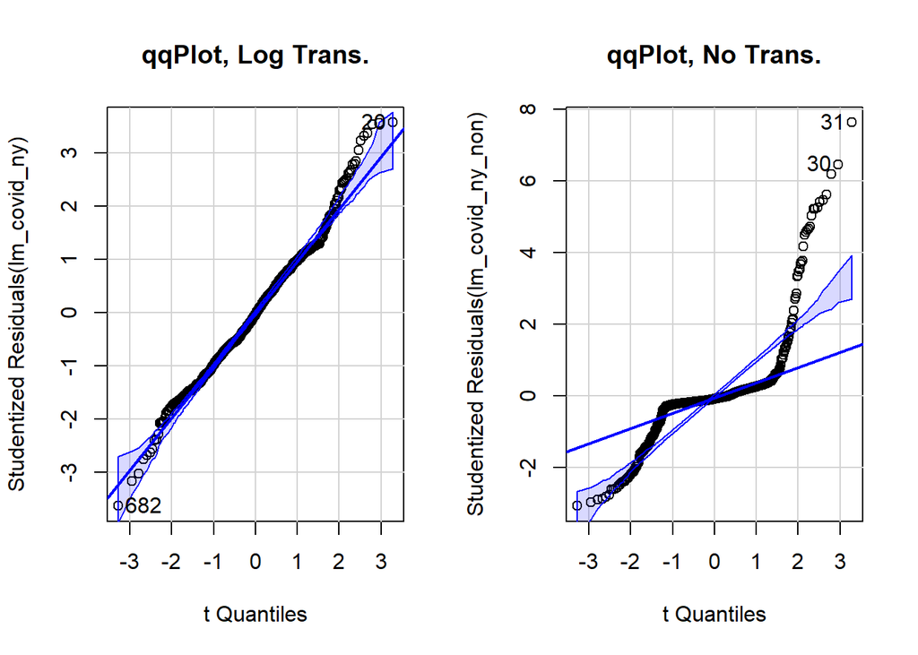

```
## 30 31
## 23 24
```

```r
qqPlot(lm_covid_ny_non, main="qqPlot, No Trans.")
```

#### Explanation

After making the log transformation the residuals appear to be more normal than before and to fit inside the bounds.

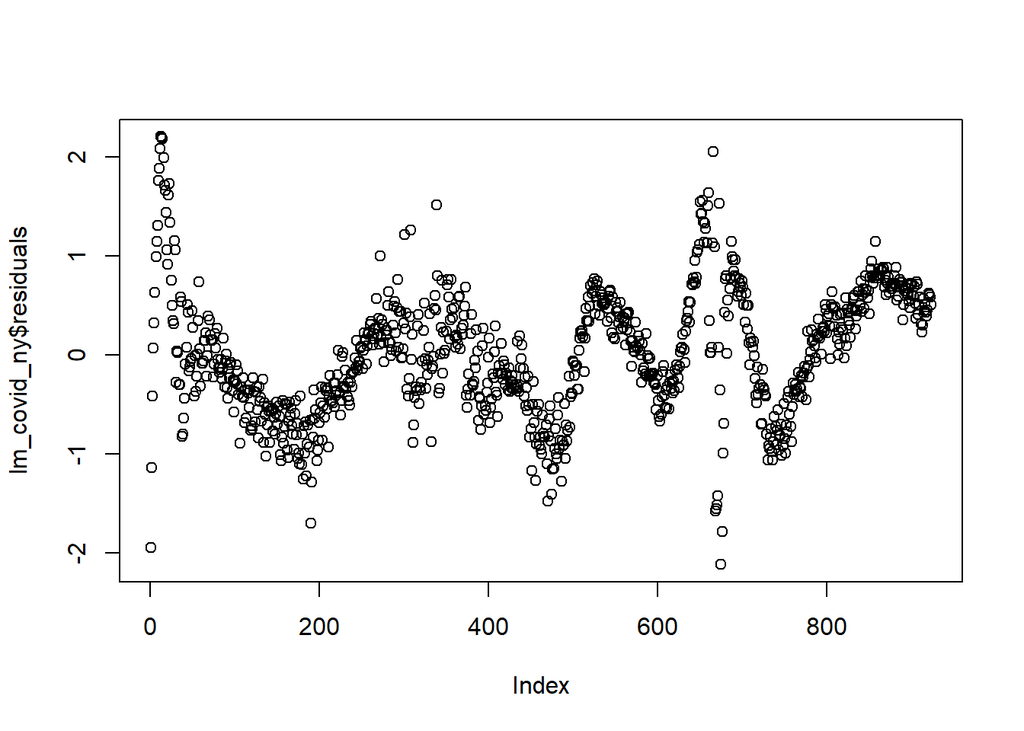

```r
plot(lm_covid_ny$residuals)
```

#### Explanation:

There does seem to be a pattern in the order and residuals; however, this is because of the natural rise and fall of cases (and with them, hospitalizations) from seasons, there are other similar viruses that follow the same pattern like the flu and common cold.

## California Data and Model

```r
cases_cali <- read_csv("cases_cali.csv", show_col_types = FALSE) %>% group_by(date) %>% summarise(probable_cases = sum(probable_cases))

hospit_cali <- read_csv("hospital_cali.csv", show_col_types = FALSE) %>% replace_na(replace = list(hospitalized_covid_confirmed_patients = 0, hospitalized_suspected_covid_patients = 0)) %>% group_by(todays_date) %>% summarise(hospitalized_covid_confirmed_patients = sum(hospitalized_covid_confirmed_patients),
          hospitalized_suspected_covid_patients = sum(hospitalized_suspected_covid_patients))

cali_hosp_cases <- hospit_cali %>% left_join(cases_cali, join_by(todays_date == date))



hosp_cali <- hosp %>%
  filter(location_key == "US_CA")

vacs_cali <- vacs %>%
  filter(location_key == "US_CA")

vacs_hosp_all_cali_data <- hosp_cali %>%
  left_join(vacs_cali, join_by("location_key"=="location_key", "date"=="date"))



data_all_cali <- cali_hosp_cases %>%  left_join(vacs_hosp_all_cali_data, join_by("todays_date"=="date")) %>%
  fill(c("new_persons_vaccinated", "new_persons_fully_vaccinated", "new_vaccine_doses_administered", "cumulative_persons_vaccinated", "cumulative_persons_fully_vaccinated", "cumulative_vaccine_doses_administered"), .direction="down") %>%
  replace_na(replace = list("new_hospitalized_patients" = 0, "current_hospitalized_patients" = 0,
                            "new_ventilator_patients" = 0, "current_ventilator_patients" = 0,
                            "new_persons_vaccinated" = 0,"new_persons_fully_vaccinated" = 0,
                            "new_vaccine_doses_administered" = 0, "cumulative_hospitalized_patients" = 0,
                            "cumulative_ventilator_patients" = 0, "cumulative_persons_vaccinated" = 0,
                            "cumulative_persons_fully_vaccinated" = 0, "cumulative_vaccine_doses_administered" = 0)) %>%
  select(-contains("pfizer"), -contains("moderna"), -contains("janssen"),
         -contains("sinovac"), -c("location_key"), -contains("intensive"),
         -c("new_ventilator_patients", "location_key", "cumulative_ventilator_patients"),
         -contains("vaccine_doses"))




cases <- data_all_cali %>% select(todays_date, hospitalized_covid_confirmed_patients, hospitalized_suspected_covid_patients)
everything_else <- data_all_cali %>% select(!c(hospitalized_covid_confirmed_patients, hospitalized_suspected_covid_patients))

everything_else_up7 <- everything_else  %>% mutate(
  todays_date = lubridate::as_date(todays_date) + 7
)

adjusted_dates_complete_cali <- cases %>% left_join(everything_else_up7, by="todays_date")
adjusted_dates_complete_cali <- adjusted_dates_complete_cali[9:1151, ] %>%
  mutate(
    full_vacs_G_mean = factor(ifelse(cumulative_persons_fully_vaccinated > mean(cumulative_persons_fully_vaccinated), "fullVacs>Mean", "fullVacs<Mean")),
    ventilator_patients = factor(ifelse(current_ventilator_patients > 0, "VentPat", "NoVentPat")),
    HOSPITALIZED_COUNT = hospitalized_covid_confirmed_patients,
    CASE_COUNT = probable_cases
  ) %>%
  select(todays_date, HOSPITALIZED_COUNT, hospitalized_covid_confirmed_patients, CASE_COUNT, probable_cases, full_vacs_G_mean, ventilator_patients, cumulative_persons_fully_vaccinated, current_ventilator_patients)
```

**Data Set Information**

- The `hospitalized_covid_confirmed_patients` and `probable_cases` columns come from these links ([hospital](https://data.ca.gov/dataset/covid-19-hospital-data), [cases](https://data.ca.gov/dataset/covid-19-probable-cases-archived)) and show the count of hospitalizations and cases for covid-19 on a given day.
- The `full_vacs_G_mean` is a True/False factor that shows if the `cumulative_persons_fully_vaccinated` is greater than its mean, in this case the mean was a little over 17 million.
- I also set this data set forward by 7 days with the same reasons as the New York Data.
- I tried getting similar data to the New York data and even went on the California equivalent website, but the data doesn’t seem to match up super well because the counts for hospitalizations is much higher and the case count is lower.

The other Data in the table I got from [Covid Vaccine and Specific Hospital Data Sets](https://github.com/GoogleCloudPlatform/covid-19-open-data/tree/main/docs).

#### Table

```r
DT::datatable(adjusted_dates_complete_cali %>% select(todays_date, hospitalized_covid_confirmed_patients, probable_cases, full_vacs_G_mean, ventilator_patients))
```

|  | todays_date | hospitalized_covid_confirmed_patients | probable_cases | full_vacs_G_mean | ventilator_patients |
| --- | --- | --- | --- | --- | --- |
| 1 | 2020-04-05 | 2509 | 2 | fullVacs&lt;Mean | NoVentPat |
| 2 | 2020-04-06 | 2611 | 4 | fullVacs&lt;Mean | NoVentPat |
| 3 | 2020-04-07 | 2714 | 6 | fullVacs&lt;Mean | NoVentPat |
| 4 | 2020-04-08 | 2825 | 2 | fullVacs&lt;Mean | NoVentPat |
| 5 | 2020-04-09 | 2897 | 4 | fullVacs&lt;Mean | NoVentPat |
| 6 | 2020-04-10 | 2846 | 4 | fullVacs&lt;Mean | NoVentPat |
| 7 | 2020-04-11 | 2917 | 0 | fullVacs&lt;Mean | NoVentPat |
| 8 | 2020-04-12 | 3015 | 4 | fullVacs&lt;Mean | NoVentPat |
| 9 | 2020-04-13 | 3124 | 0 | fullVacs&lt;Mean | NoVentPat |
| 10 | 2020-04-14 | 3171 | 2 | fullVacs&lt;Mean | NoVentPat |

[output cut: 1133 more lines]

### Making the Model

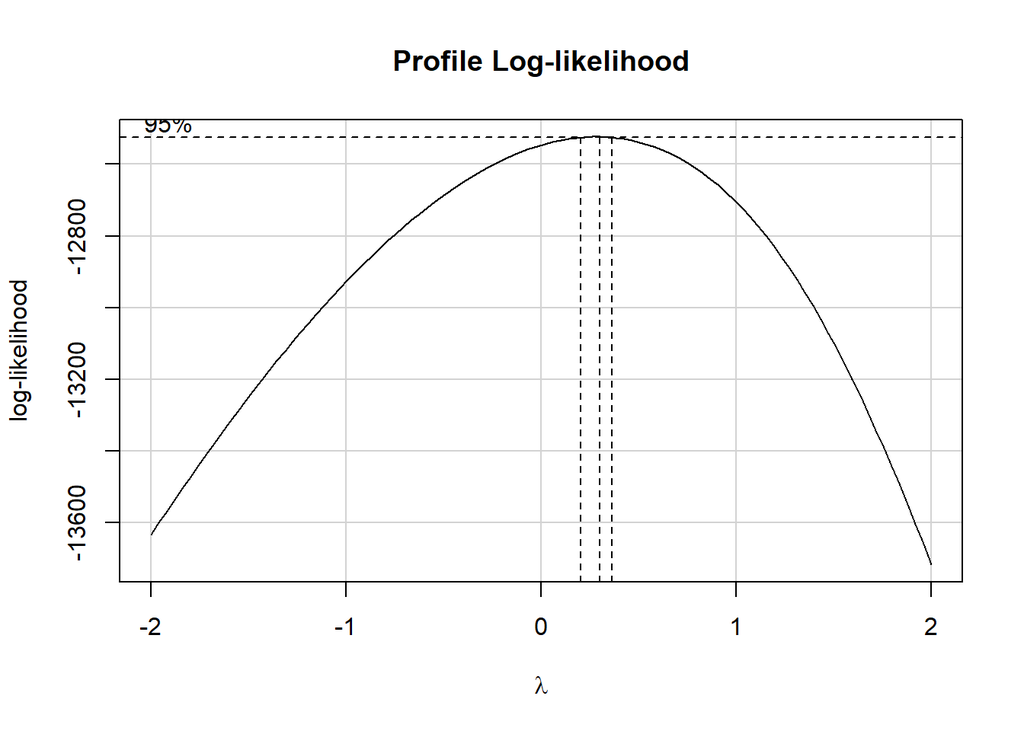

```r
lm_covid_cali_non <- lm(HOSPITALIZED_COUNT~(CASE_COUNT) + CASE_COUNT:full_vacs_G_mean, adjusted_dates_complete_cali)

boxCox(lm_covid_cali_non)
```

The $\lambda$ appears to be around .25 so I will make a sqrt-sqrt transformation.

```r
lm_covid_cali <- lm(sqrt(sqrt(HOSPITALIZED_COUNT))~(CASE_COUNT) + CASE_COUNT:full_vacs_G_mean, adjusted_dates_complete_cali)
summary(lm_covid_cali)
```

```
##
## Call:
## lm(formula = sqrt(sqrt(HOSPITALIZED_COUNT)) ~ (CASE_COUNT) +
##     CASE_COUNT:full_vacs_G_mean, data = adjusted_dates_complete_cali)
##
## Residuals:
##     Min      1Q  Median      3Q     Max
## -2.4403 -0.7745 -0.0263  0.5427  3.1915
##
## Coefficients:
##                                            Estimate Std. Error t value Pr(>|t|)
## (Intercept)                               7.072e+00  3.408e-02  207.50   <2e-16
## CASE_COUNT                                1.248e-03  3.614e-05   34.53   <2e-16
## CASE_COUNT:full_vacs_G_meanfullVacs>Mean -1.049e-03  3.584e-05  -29.27   <2e-16
##
## (Intercept)                              ***
## CASE_COUNT                               ***
## CASE_COUNT:full_vacs_G_meanfullVacs>Mean ***
## ---
## Signif. codes:  0 '***' 0.001 '**' 0.01 '*' 0.05 '.' 0.1 ' ' 1
##
## Residual standard error: 0.9741 on 1140 degrees of freedom
## Multiple R-squared:   0.56,  Adjusted R-squared:  0.5592
## F-statistic: 725.5 on 2 and 1140 DF,  p-value: < 2.2e-16
```

```r
b_cali <- coef(lm_covid_cali)
```

All of the features used show significant p-values below 0.001 and are getting very close to 0, so they would be able to be used even with the lowest significance level on the summary. The R-squared is around .56 which shows a moderate to strong correlation and by looking at the slope estimates we can see that it is a positive correlation between CASE_COUNT and HOSPITALIZED_COUNT, or in this instance `hospitalized_covid_confirmed_patients` and `probable_cases`.

For the same reason as before, I believe that the factor cumulative full vaccinations being greater than the mean (17 million in this case) isn’t completely about vaccinations but could be due to other factors, such as time of year and time after the pandemic began.

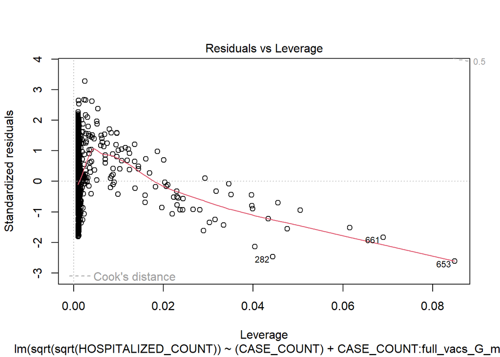

```r
plot(lm_covid_cali, which=c(5))
```

#### Explanation:

In the Cook’s distance graph above, none of the points go out of the .5 bounds so I will not make any adjustments to the data.

In this model I did not include the Patients on Ventilator in the hospitals. According to the data, the `current_ventilator_patients` column only contains 0s so I couldn’t use it in the model because there would only be one category.

### Graphing the Model

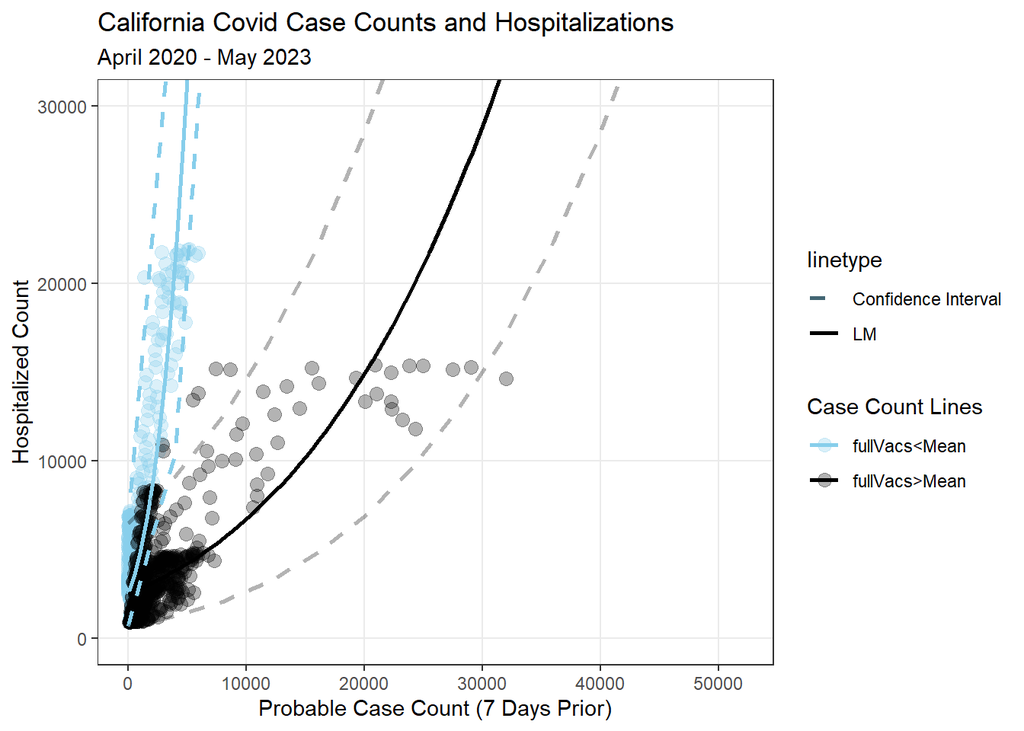

```r
drawit_cali <- function(CASE_COUNT, fullVacsMean = 0){
  (b_cali[1] + b_cali[2]*CASE_COUNT + b_cali[3]*CASE_COUNT*fullVacsMean)^4
}

get_pred <- function(fullVacsMean = "fullVacs<Mean"){
  CASE_COUNT <- seq(0, max(adjusted_dates_complete$CASE_COUNT), 4000)
  fullVacs_list <- rep(c(fullVacsMean),(max(adjusted_dates_complete$CASE_COUNT)/4000)+1)

  allpreds <- (predict(lm_covid_cali, data.frame(CASE_COUNT=CASE_COUNT, full_vacs_G_mean=fullVacs_list), interval="prediction"))^4

  allpreds <- data.frame(allpreds, CASE_COUNT = CASE_COUNT, fullVacsMean = fullVacs_list)

  return(allpreds)
}

allpreds_blue <- get_pred("fullVacs<Mean")
allpreds_black <- get_pred("fullVacs>Mean")


ggplot(adjusted_dates_complete_cali, aes(x=CASE_COUNT, y=HOSPITALIZED_COUNT)) +
  geom_point(aes(color=interaction(full_vacs_G_mean)), alpha=.3, size=3) +
  scale_color_manual(values=c("skyblue", "black")) +
  stat_function(fun=drawit_cali, args=list(fullVacsMean=0), aes(color="fullVacs<Mean", linetype="LM"), linewidth=1) +
  stat_function(fun=drawit_cali, args=list(fullVacsMean=1), aes(color="fullVacs>Mean", linetype="LM"), linewidth=1) +
  geom_line(data=allpreds_blue, mapping=aes(x=CASE_COUNT, y=lwr, linetype="Confidence Interval"), color="skyblue", linewidth=1) +
  geom_line(data=allpreds_blue, mapping=aes(x=CASE_COUNT, y=upr, linetype="Confidence Interval"), color="skyblue", linewidth=1) +
  geom_line(data=allpreds_black, mapping=aes(x=CASE_COUNT, y=lwr, linetype="Confidence Interval"), color="black", linewidth=1, alpha=.3) +
  geom_line(data=allpreds_black, mapping=aes(x=CASE_COUNT, y=upr, linetype="Confidence Interval"), color="black", linewidth=1, alpha=.3) +
  scale_linetype_manual(values=c("Confidence Interval" = 2, "LM" = 1)) +
  guides(color=guide_legend(title="Case Count Lines")) +
  coord_cartesian(ylim=c(0,30000)) +
  # facet_wrap(~interaction(full_vacs_G_mean, ventilator_patients)) +
  labs(
    x = "Probable Case Count (7 Days Prior)",
    y = "Hospitalized Count",
    title = "California Covid Case Counts and Hospitalizations",
    subtitle = "April 2020 - May 2023"
  ) +
  theme_bw() +
  theme(panel.grid.minor = element_blank(),
        title = element_text(hjust=.5))
```

#### California Model Explanation

I decided to look at two different parts of the graph for this since it can have varying slopes based on where it is on the graph.

**Blue Line:** When the amount of full vaccinations is not greater than the mean in the data set (7 days prior to hospitalization predictions), the predicted count of hospitalizations, due to covid, go up by (from 1 to 2 covid cases) $1.7667352$ per additional probable covid case.

From 3000 to 3001 covid cases $6.3165154$ per additional probable covid case.

**Black Line:** When the amount of full vaccinations is greater than the mean in the data set (7 days prior to hospitalization predictions), the predicted count of hospitalizations, due to covid, go up by (from 1 to 2 covid cases) $0.2815673$ per additional probable covid case. This means that it estimates for about every 4 additional cases it is predicted that there will be 1 additional hospitalization.

**Additional Information** These estimations are very different than the New York estimations, this may lead to a problem with validating across data sets.

### Assumptions

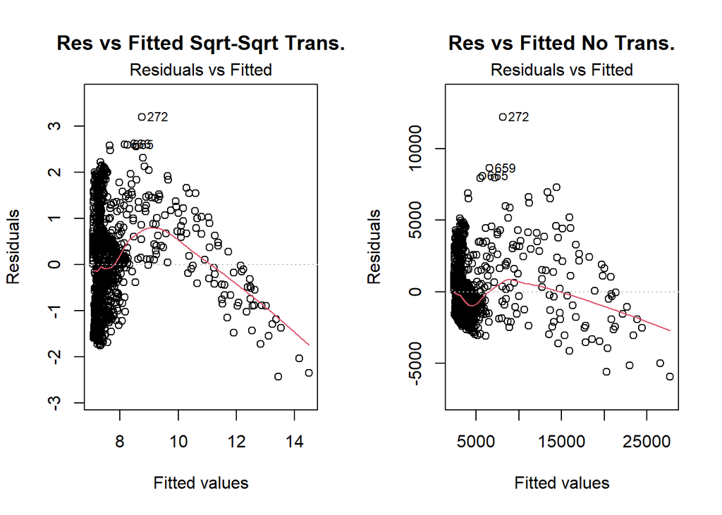

```r
par(mfcol=c(1,2))
plot(lm_covid_cali, which=1, main="Res vs Fitted Sqrt-Sqrt Trans.")
plot(lm_covid_cali_non, which=1, main="Res vs Fitted No Trans.")
```

#### Explanation

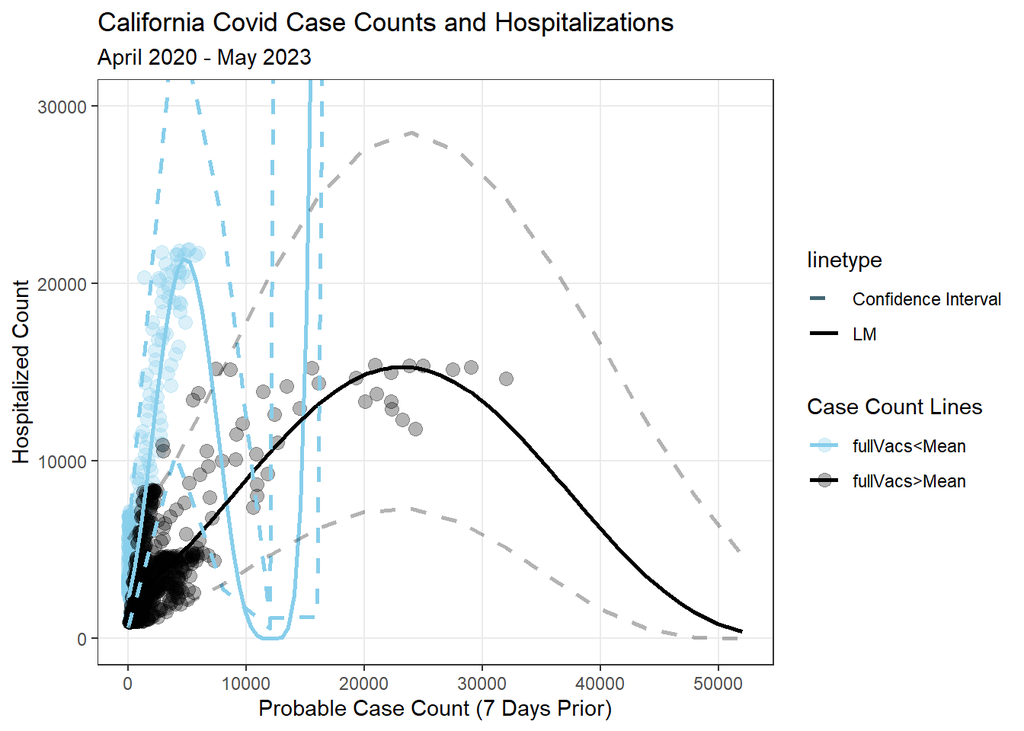

```r
lm_covid_cali2 <- lm(sqrt(sqrt(HOSPITALIZED_COUNT))~CASE_COUNT + CASE_COUNT:full_vacs_G_mean + I(CASE_COUNT^2):full_vacs_G_mean, adjusted_dates_complete_cali)

b_cali <- coef(lm_covid_cali2)

drawit_cali <- function(CASE_COUNT, fullVacsMean = 0){
  (b_cali[1] + b_cali[2]*CASE_COUNT + b_cali[3]*CASE_COUNT*fullVacsMean + b_cali[4]*CASE_COUNT^2*(fullVacsMean*-1+1) + b_cali[5]*CASE_COUNT^2*fullVacsMean)^4
}

get_pred <- function(fullVacsMean = "fullVacs<Mean"){
  CASE_COUNT <- seq(0, max(adjusted_dates_complete$CASE_COUNT), 4000)
  fullVacs_list <- rep(c(fullVacsMean),(max(adjusted_dates_complete$CASE_COUNT)/4000)+1)

  allpreds <- (predict(lm_covid_cali2, data.frame(CASE_COUNT=CASE_COUNT, full_vacs_G_mean=fullVacs_list), interval="prediction"))^4

  allpreds <- data.frame(allpreds, CASE_COUNT = CASE_COUNT, fullVacsMean = fullVacs_list)

  return(allpreds)
}

allpreds_blue <- get_pred("fullVacs<Mean")
allpreds_black <- get_pred("fullVacs>Mean")


ggplot(adjusted_dates_complete_cali, aes(x=CASE_COUNT, y=HOSPITALIZED_COUNT)) +
  geom_point(aes(color=interaction(full_vacs_G_mean)), alpha=.3, size=3) +
  scale_color_manual(values=c("skyblue", "black")) +
  stat_function(fun=drawit_cali, args=list(fullVacsMean=0), aes(color="fullVacs<Mean", linetype="LM"), linewidth=1) +
  stat_function(fun=drawit_cali, args=list(fullVacsMean=1), aes(color="fullVacs>Mean", linetype="LM"), linewidth=1) +
  geom_line(data=allpreds_blue, mapping=aes(x=CASE_COUNT, y=lwr, linetype="Confidence Interval"), color="skyblue", linewidth=1) +
  geom_line(data=allpreds_blue, mapping=aes(x=CASE_COUNT, y=upr, linetype="Confidence Interval"), color="skyblue", linewidth=1) +
  geom_line(data=allpreds_black, mapping=aes(x=CASE_COUNT, y=lwr, linetype="Confidence Interval"), color="black", linewidth=1, alpha=.3) +
  geom_line(data=allpreds_black, mapping=aes(x=CASE_COUNT, y=upr, linetype="Confidence Interval"), color="black", linewidth=1, alpha=.3) +
  scale_linetype_manual(values=c("Confidence Interval" = 2, "LM" = 1)) +
  guides(color=guide_legend(title="Case Count Lines")) +
  coord_cartesian(ylim=c(0,30000)) +
  # facet_wrap(~interaction(full_vacs_G_mean, ventilator_patients)) +
  labs(
    x = "Probable Case Count (7 Days Prior)",
    y = "Hospitalized Count",
    title = "California Covid Case Counts and Hospitalizations",
    subtitle = "April 2020 - May 2023"
  ) +
  theme_bw() +
  theme(panel.grid.minor = element_blank(),
        title = element_text(hjust=.5))
```

```r
par(mfcol=c(1,2))
qqPlot(lm_covid_cali, main="qqPlot, Sqrt-Sqrt Trans.")
```

```
## [1] 272 666
```

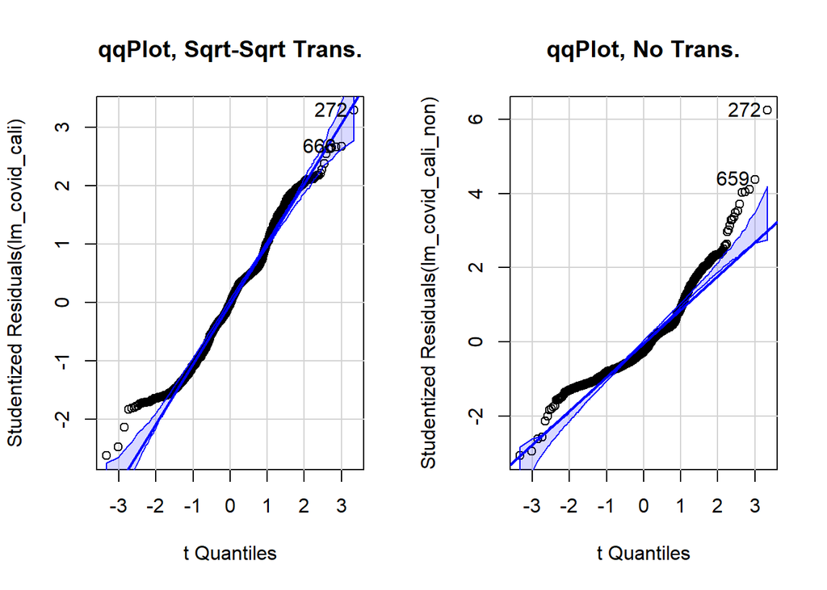

```
## [1] 272 659
```

```r
qqPlot(lm_covid_cali_non, main="qqPlot, No Trans.")
```

#### Explanation

The residuals appear to become slightly better with the transformation; however, it does snake across the middle so there could be a problem with that. But we will continue with the study.

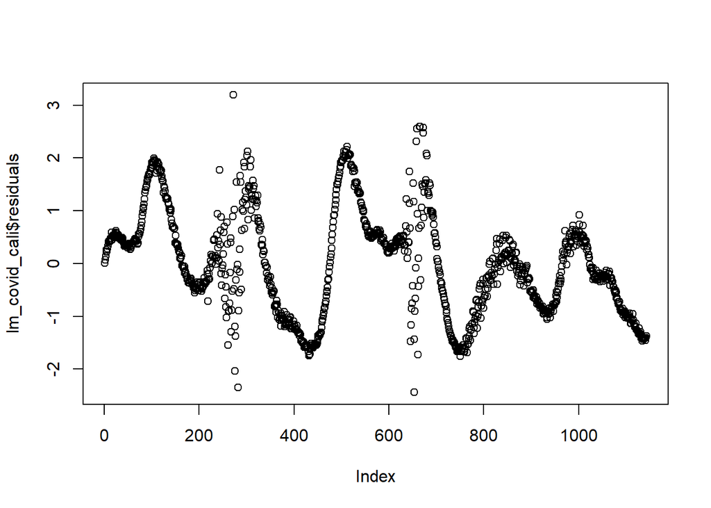

```r
plot(lm_covid_cali$residuals)
```

#### Explanation:

The reason is the same here, but I will reiterate it:

There does seem to be a pattern in the order and residuals; however, this is because of the natural rise and fall of cases (and with them, hospitalizations) from seasons, there are other similar viruses that follow the same pattern like the flu and common cold.

## Validation for Models

```r
set.seed(121)

num_rows <- 700 #1460 total
keep <- sample(1:nrow(adjusted_dates_complete), num_rows)

mytrain <- adjusted_dates_complete[keep, ] #Use this in the lm(..., data=mytrain) it is like "rbdata"

mytest <- adjusted_dates_complete[-keep, ] #Use this in the predict(..., newdata=mytest) it is like "rbdata2"

model <- lm(log(HOSPITALIZED_COUNT)~(CASE_COUNT) + CASE_COUNT:full_vacs_G_mean + CASE_COUNT:ventilator_patients, data=mytrain)
model_non <- lm(HOSPITALIZED_COUNT~(CASE_COUNT) + CASE_COUNT:full_vacs_G_mean + CASE_COUNT:ventilator_patients, data=mytrain)

thedata2 <- mytest
# Get y-hat for each model on new data.
yme <- exp(predict(model, newdata=thedata2))
yme_non <- (predict(model_non, newdata=thedata2))

# Compute y-bar
ybar <- (mean(thedata2$HOSPITALIZED_COUNT)) #Yi is given by Ynew from the new sample of data

# Compute SSTO
SSTO <- sum((thedata2$HOSPITALIZED_COUNT - ybar)^2)

# Compute SSE for each model using y - yhat
SSEme <- sum((thedata2$HOSPITALIZED_COUNT - yme)^2)
SSEme_non <- sum((thedata2$HOSPITALIZED_COUNT - yme_non)^2)

# Compute R-squared for each
rsme <- 1 - SSEme/SSTO
rsme_non <- 1 - SSEme_non/SSTO

# Compute adjusted R-squared for each
n <- length(thedata2$HOSPITALIZED_COUNT) #sample size
pme <- length(coef(model)) #num. parameters in model
rsmea <- 1 - (n-1)/(n-pme)*SSEme/SSTO
pme_non <- length(coef(model_non)) #num. parameters in model
rsmea_non <- 1 - (n-1)/(n-pme_non)*SSEme_non/SSTO


my_output_table2 <- data.frame(Model = c("New York Model Log Trans.", "New York Model Non Trans."), `Original R2` = c(summary(model)$r.squared, summary(model_non)$r.squared), `Orig. Adj. R-squared` = c(summary(model)$adj.r.squared, summary(model_non)$adj.r.squared), `Validation R-squared` = c(rsme, rsme_non), `Validation Adj. R^2` = c(rsmea, rsmea_non))

colnames(my_output_table2) <- c("Model", "Original $R^2$", "Original Adj. $R^2$", "Validation $R^2$", "Validation Adj. $R^2$")

knitr::kable(my_output_table2, escape=TRUE, digits=4)
```

| Model | Original $R^2$ | Original Adj. $R^2$ | Validation $R^2$ | Validation Adj. $R^2$ |
| --- | --- | --- | --- | --- |
| New York Model Log Trans. | 0.6168 | 0.6152 | -1.4786 | -1.5126 |
| New York Model Non Trans. | 0.6475 | 0.6460 | 0.6787 | 0.6743 |

```r
set.seed(121)

num_rows <- 850 #1460 total
keep <- sample(1:nrow(adjusted_dates_complete), num_rows)

mytrain <- adjusted_dates_complete_cali[keep, ] #Use this in the lm(..., data=mytrain) it is like "rbdata"

mytest <- adjusted_dates_complete_cali[-keep, ] #Use this in the predict(..., newdata=mytest) it is like "rbdata2"

model <- lm(sqrt(sqrt(HOSPITALIZED_COUNT))~(CASE_COUNT) + CASE_COUNT:full_vacs_G_mean, data=mytrain)
model_non <- lm(HOSPITALIZED_COUNT~(CASE_COUNT) + CASE_COUNT:full_vacs_G_mean, data=mytrain)

thedata2 <- mytest
# Get y-hat for each model on new data.
yme <- (predict(model, newdata=thedata2))^4
yme_non <- (predict(model_non, newdata=thedata2))

# Compute y-bar
ybar <- (mean(thedata2$HOSPITALIZED_COUNT)) #Yi is given by Ynew from the new sample of data

# Compute SSTO
SSTO <- sum((thedata2$HOSPITALIZED_COUNT - ybar)^2)

# Compute SSE for each model using y - yhat
SSEme <- sum((thedata2$HOSPITALIZED_COUNT - yme)^2)
SSEme_non <- sum((thedata2$HOSPITALIZED_COUNT - yme_non)^2)

# Compute R-squared for each
rsme <- 1 - SSEme/SSTO
rsme_non <- 1 - SSEme_non/SSTO

# Compute adjusted R-squared for each
n <- length(thedata2$HOSPITALIZED_COUNT) #sample size
pme <- length(coef(model)) #num. parameters in model
rsmea <- 1 - (n-1)/(n-pme)*SSEme/SSTO
pme_non <- length(coef(model_non)) #num. parameters in model
rsmea_non <- 1 - (n-1)/(n-pme_non)*SSEme_non/SSTO


my_output_table2 <- data.frame(Model = c("California Model Sqrt-Sqrt Trans.", "California Model Non Trans."), `Original R2` = c(summary(model)$r.squared, summary(model_non)$r.squared), `Orig. Adj. R-squared` = c(summary(model)$adj.r.squared, summary(model_non)$adj.r.squared), `Validation R-squared` = c(rsme, rsme_non), `Validation Adj. R^2` = c(rsmea, rsmea_non))

colnames(my_output_table2) <- c("Model", "Original $R^2$", "Original Adj. $R^2$", "Validation $R^2$", "Validation Adj. $R^2$")

knitr::kable(my_output_table2, escape=TRUE, digits=4)
```

| Model | Original $R^2$ | Original Adj. $R^2$ | Validation $R^2$ | Validation Adj. $R^2$ |
| --- | --- | --- | --- | --- |
| California Model Sqrt-Sqrt Trans. | 0.5630 | 0.5620 | 0.5316 | 0.5283 |
| California Model Non Trans. | 0.7634 | 0.7628 | 0.6612 | 0.6589 |

The R-squared for the New York transformed model is very bad, this is most likely due to over fitting, the transformation might have had something to do with this. The non-transformed New York model does validate well and even rises in its R-squared by around .03.

The R-squared for the California transformed model did much better and only dropped slightly, by about .03. It seems the transformation fitted the California model much better than the New York model. The R-squared for the non-transformed California model begins better but drops more than the transformed model by about .1.

## Validation On Others Data

```r
set.seed(121)

mytrain <- adjusted_dates_complete #Use this in the lm(..., data=mytrain) it is like "rbdata"

mytest <- adjusted_dates_complete_cali #Use this in the predict(..., newdata=mytest) it is like "rbdata2"

model <- lm(log(HOSPITALIZED_COUNT)~(CASE_COUNT) + CASE_COUNT:full_vacs_G_mean + CASE_COUNT:ventilator_patients, data=mytrain)
model_non <- lm(HOSPITALIZED_COUNT~(CASE_COUNT) + CASE_COUNT:full_vacs_G_mean + CASE_COUNT:ventilator_patients, data=mytrain)

thedata2 <- mytest
# Get y-hat for each model on new data.
yme <- exp(predict(model, newdata=thedata2))
yme_non <- (predict(model_non, newdata=thedata2))

# Compute y-bar
ybar <- (mean(thedata2$HOSPITALIZED_COUNT)) #Yi is given by Ynew from the new sample of data

# Compute SSTO
SSTO <- sum((thedata2$HOSPITALIZED_COUNT - ybar)^2)

# Compute SSE for each model using y - yhat
SSEme <- sum((thedata2$HOSPITALIZED_COUNT - yme)^2)
SSEme_non <- sum((thedata2$HOSPITALIZED_COUNT - yme_non)^2)

# Compute R-squared for each
rsme <- 1 - SSEme/SSTO
rsme_non <- 1 - SSEme_non/SSTO

# Compute adjusted R-squared for each
n <- length(thedata2$HOSPITALIZED_COUNT) #sample size
pme <- length(coef(model)) #num. parameters in model
rsmea <- 1 - (n-1)/(n-pme)*SSEme/SSTO
pme_non <- length(coef(model_non)) #num. parameters in model
rsmea_non <- 1 - (n-1)/(n-pme_non)*SSEme_non/SSTO


my_output_table2 <- data.frame(Model = c("New York Model Log Trans.\n on California Model", "New York Model Non Trans.\n on California Model"), `Original R2` = c(summary(model)$r.squared, summary(model_non)$r.squared), `Orig. Adj. R-squared` = c(summary(model)$adj.r.squared, summary(model_non)$adj.r.squared), `Validation R-squared` = c(rsme, rsme_non), `Validation Adj. R^2` = c(rsmea, rsmea_non))

colnames(my_output_table2) <- c("Model", "Original $R^2$", "Original Adj. $R^2$", "Validation $R^2$", "Validation Adj. $R^2$")

knitr::kable(my_output_table2, escape=TRUE, digits=4)
```

| Model | Original $R^2$ | Original Adj. $R^2$ | Validation $R^2$ | Validation Adj. $R^2$ |
| --- | --- | --- | --- | --- |
| New York Model Log Trans. |  |  |  |  |
| on California Model | 0.6303 | 0.6291 | -1.0548 | -1.0603 |
| New York Model Non Trans. |  |  |  |  |
| on California Model | 0.6562 | 0.6551 | -1.0268 | -1.0321 |

```r
set.seed(121)

mytrain <- adjusted_dates_complete_cali #Use this in the lm(..., data=mytrain) it is like "rbdata"

mytest <- adjusted_dates_complete #Use this in the predict(..., newdata=mytest) it is like "rbdata2"

model <- lm(sqrt(sqrt(HOSPITALIZED_COUNT))~(CASE_COUNT) + CASE_COUNT:full_vacs_G_mean, data=mytrain)
model_non <- lm(HOSPITALIZED_COUNT~(CASE_COUNT) + CASE_COUNT:full_vacs_G_mean, data=mytrain)

thedata2 <- mytest
# Get y-hat for each model on new data.
yme <- (predict(model, newdata=thedata2))^4
yme_non <- (predict(model_non, newdata=thedata2))

# Compute y-bar
ybar <- (mean(thedata2$HOSPITALIZED_COUNT)) #Yi is given by Ynew from the new sample of data

# Compute SSTO
SSTO <- sum((thedata2$HOSPITALIZED_COUNT - ybar)^2)

# Compute SSE for each model using y - yhat
SSEme <- sum((thedata2$HOSPITALIZED_COUNT - yme)^2)
SSEme_non <- sum((thedata2$HOSPITALIZED_COUNT - yme_non)^2)

# Compute R-squared for each
rsme <- 1 - SSEme/SSTO
rsme_non <- 1 - SSEme_non/SSTO

# Compute adjusted R-squared for each
n <- length(thedata2$HOSPITALIZED_COUNT) #sample size
pme <- length(coef(model)) #num. parameters in model
rsmea <- 1 - (n-1)/(n-pme)*SSEme/SSTO
pme_non <- length(coef(model_non)) #num. parameters in model
rsmea_non <- 1 - (n-1)/(n-pme_non)*SSEme_non/SSTO


my_output_table2 <- data.frame(Model = c("California Model Sqrt-Sqrt Trans.\n on New York Data", "California Model Non Trans.\n on New York Data"), `Original R2` = c(summary(model)$r.squared, summary(model_non)$r.squared), `Orig. Adj. R-squared` = c(summary(model)$adj.r.squared, summary(model_non)$adj.r.squared), `Validation R-squared` = c(rsme, rsme_non), `Validation Adj. R^2` = c(rsmea, rsmea_non))

colnames(my_output_table2) <- c("Model", "Original $R^2$", "Original Adj. $R^2$", "Validation $R^2$", "Validation Adj. $R^2$")

knitr::kable(my_output_table2, escape=TRUE, digits=4)
```

| Model | Original $R^2$ | Original Adj. $R^2$ | Validation $R^2$ | Validation Adj. $R^2$ |
| --- | --- | --- | --- | --- |
| California Model Sqrt-Sqrt Trans. |  |  |  |  |
| on New York Data | 0.5600 | 0.5592 | -2131.125 | -2135.760 |
| California Model Non Trans. |  |  |  |  |
| on New York Data | 0.7655 | 0.7651 | -1159.622 | -1162.145 |

### Explanation:

It doesn’t appear that either should be used on the others data, since the R-squared values for each are negative. It also appears that the California model did much worse on the New York data than the New York model did on the California data, since the validation R-squared is much more negative. And the transformation for both don’t help on the validation on the others data but seem to worsen it.

The simple answer to if we can validate across states is no; however, I believe that this might be because of different state laws or guidelines during covid, population, population density, and because I used two different data sets that could have had different metrics for counting hospitalizations and case counts.

I did try to get a data set that had these different states or even with all states; however, I was not able to find a data set that had case count, hospitalizations, vaccinations, and specifics about hospitalizations so I found these that were both from their state government websites.